### **Data management related**

#### **Input data**

Two choice

1. **Example**
2. **Upload** : valid file format for upload : *csv, tsv, txt, xlsx,* or *rds*

Under the **Example** option, three datasets are provided to enable users to conduct exploratory tasks using the application. These datasets serve as representations of the data formats supported by the application. The **wide** and **long format** dataset essentially contain the same data but are presented in different structures. For more details about **wide** and **long format** refer the *Reshape* section.

On the other hand, the **replicate** data features a structure with two headers and pairs of replicates for both the *“control”* and *“treatment”*. Data with replicates can have more than one header. Such data necessitates further processing before it can be utilized for plotting figures. Refer the **Data with replicate** for more details.

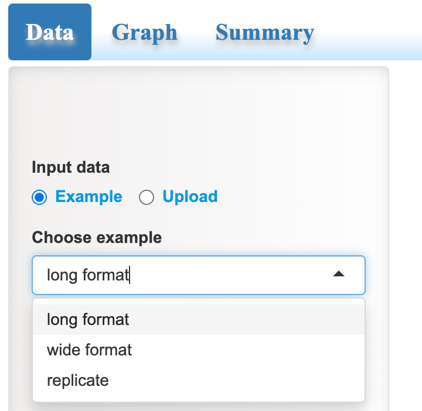

**Example datasets**

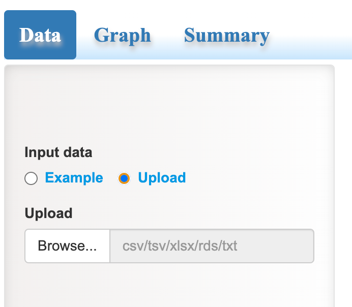

**Upload**

#### **Handle missing data**

When uploading data, users have the option to specify *single* or *multiple* missing values. **Specifying multiple missing values must be comma separated**.

Three approaches to manage missing data:

1. **Replaced with 0** : It is the default setting. It will replaced specified missing values with *0*.
2. **Removed NA** : It will eliminate the entire rows containing missing data. *It’s important to exercise caution when opting for this option.*
3. **Impute methods** : A selection of 10 imputation methods are available, which have been categorized into two groups: common and advance. This classification is solely for organization and doesn’t imply any hierarchy among the methods.

Selecting suitable imputation methods for your data is crucial. For comprehensive guidance on handling missing data, you can explore the freely available resource titled [Flexible Imputation of Missing Data](https://stefvanbuuren.name/fimd/want-the-hardcopy.html)

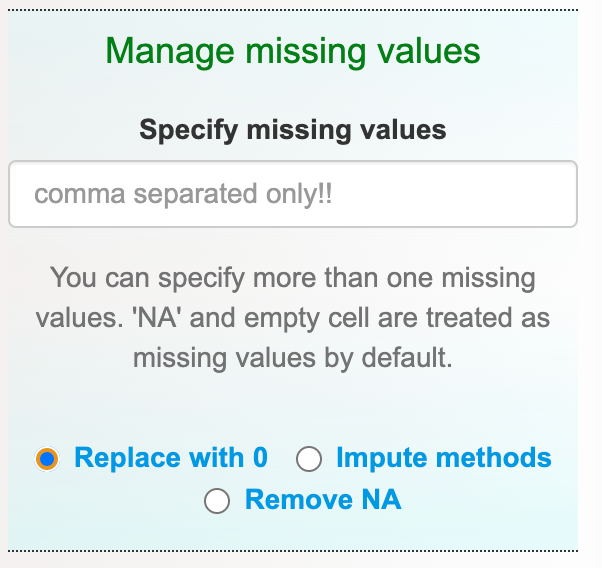

Missing values

#### **Data with replicate**

1. **Data with replicate/multiple headers?** : Select the **Yes**. This action will unveil a range of input choices designed for data processing.
2. Ensure correct number of **Header** and **Group/variable**. This is a crucial step. The **Group/variable** denotes the factor by which replicates have to be combined. For instance, in the example dataset, the replicate data features two groups/variables: *control* and *treatment*.
3. Provide **Variable name** and **Replicate columns** : By specifying the number of *variables*, the system will prompt for **Variable name** and **Replicate columns**.
4. **Compute mean or median** : Users interested in calculating the **mean** or **median** of pooled replicates can do so by selecting the appropriate options under **Compute**. The system will then prompt for specification of the variable(s) for grouping and performing the chosen computation method.
5. **Apply** : Upon furnishing all essential inputs, an **Apply** button will be presented. A simple click on this button triggers the initiation of the data processing procedure.

After processing replicate data it will add two new columns :

- New column named **replicates**, which will specify to which replicates the data belong to.
- New column using the user-provided *variable name*. Replicate value of independent variable will be placed under it.

In instances where the data features more than one variable with replicates, it’s advisable to proceed with reshaping the data for optimal representation and analysis. The processed data will be presented below the original data panel, and will be available for download as a CSV file.

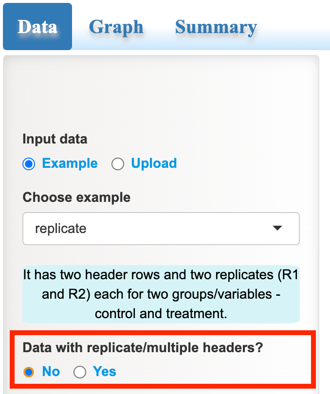

**Choose “Yes”**

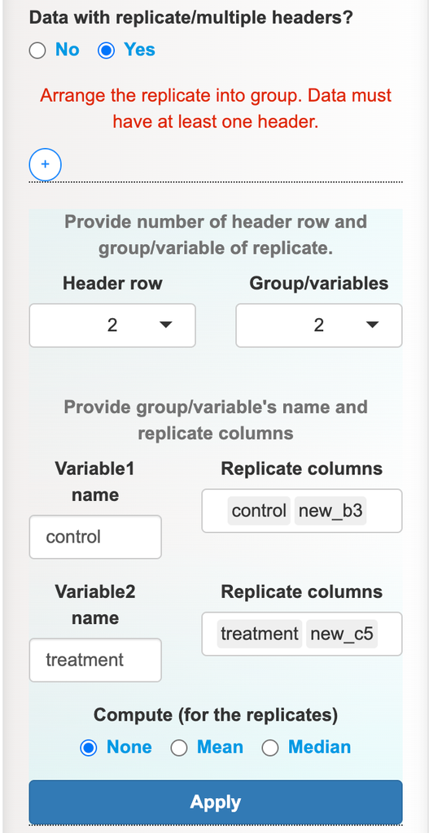

**Fill the parameters**

#### **Reshape wide to long format**

The choice between **wide** and **long** data formats depends on the analysis. While **wide format** is suitable for creating scatter or line graphs, **long format** is generally preferred for most cases. The primary distinction between wide and long formats lies in the organization of variables.

**Wide format**: Value of independent variable is the column name i.e. column headers are value ( *Table 1*).

**Long format**: Also known as tidy format. Each variable forms a column and each observation forms a row ( *Table 2* ). Both independent and dependent variables are organized into distinct columns. Opting for the long format allows for inclusion of multiple variables in separate columns within the dataset. This, in turn, grants the flexibility to dynamically compare variables and analyze data interactively using PlotS.

| Table 1. Wide format table. Each independent variable forms the columns (ctrl, trt1, trt2) and each cell is the record of dependent variable i.e. weight ctrl | Table 1. Wide format table. Each independent variable forms the columns (ctrl, trt1, trt2) and each cell is the record of dependent variable i.e. weight trt1 | Table 1. Wide format table. Each independent variable forms the columns (ctrl, trt1, trt2) and each cell is the record of dependent variable i.e. weight trt2 |
| --- | --- | --- |
| 4.17 | 4.81 | 6.31 |
| 5.58 | 4.17 | 5.12 |
| 5.18 | 4.41 | 5.54 |

| Table 2. Long format table. The independent variables (ctrl, trt1, and trt2) are grouped under the category 'group', while the dependent variable is positioned under 'value'. group | Table 2. Long format table. The independent variables (ctrl, trt1, and trt2) are grouped under the category 'group', while the dependent variable is positioned under 'value'. value |
| --- | --- |
| ctrl | 4.17 |
| ctrl | 5.58 |
| ctrl | 5.18 |
| trt1 | 4.81 |
| trt1 | 4.17 |
| trt1 | 4.41 |
| trt2 | 6.31 |
| trt2 | 5.12 |
| trt2 | 5.54 |

Wide format can be reshaped into long format by using the **Reshape** feature.

- **Specify the columns to reshape**: Users need to first specify the column to reshape. The name of the chosen columns will serve as the different levels of independent variables, and the corresponding value (dependent variable) will be placed in a separate column called “value”.
- **Enter name**: Users also need to provide a new name of column for housing the independent variables.
- **Reshape**: Apply the reshape by clicking the **Reshape** button.

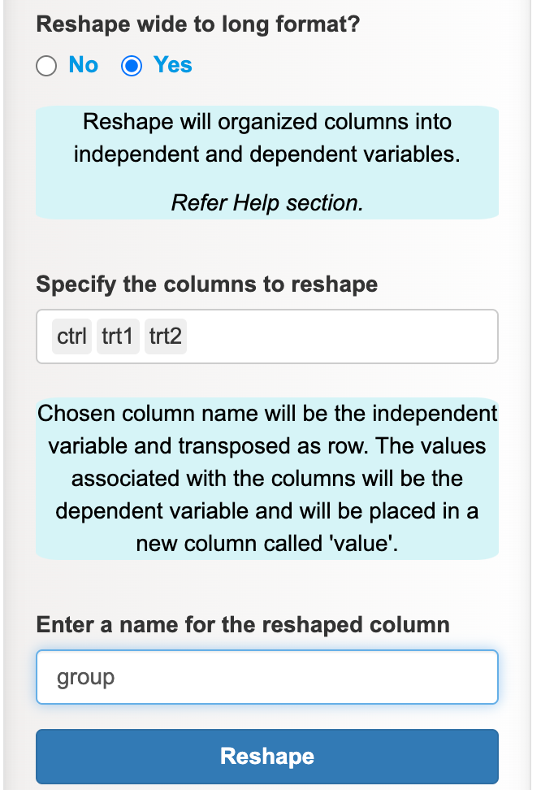

Reshape feature

#### **Data transformation**

The tool provides different methods for transforming data. Here’s some details of the feature:

1. **Method selection:** Users can select a data transformation method from a dropdown menu. The available methods are:
   - log2: it add +1 to all the value if there is 0 in the data.
   - log10: it add +1 to all the value if there is 0 in the data.
   - square-root
   - box-cox
   - scale
2. **Variable selection:** The tool automatically identifies numeric variables from the input data and generates a list of these variables. Users can select one or more variables from the list to be transformed.
3. **Box-Cox transformation:** The “box-cox” method has a specific requirement. It needs two variables:
   - Categorical variable
   - Numeric variable
4. **Overwriting:** Data transformation will overwrite the other data processing methods (reshaped and replicate data).
5. **Reverting to original data:** Users can revert to their original data state by selecting the ” *none*” option from the transformation method dropdown.
6. **Transformed data display:** The transformed data will be displayed below the panel of input data.
7. **Download:** Users can download the transformed data as a CSV file.

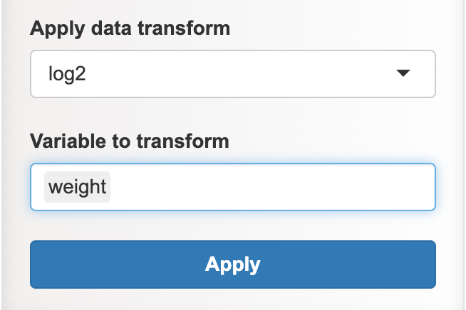

Transformation feature